# Welcome to the University of Southampton

The University of Southampton is a world-leading institution, renowned for its academic excellence, innovative research, and stunning campus location in the heart of Southampton. As one of the UK’s top 10 universities, we’re dedicated to providing a world-class education and a supportive community for our students.

## Our Five Faculties

At Southampton, we’re home to five main faculties:

- Arts and Humanities
- Business
- Engineering and Physical Sciences
- Environmental and Life Sciences
- Medicine

Each faculty offers a range of undergraduate and postgraduate programs, tailored to your interests and career aspirations. With cutting-edge facilities and expert staff, you’ll get the skills and knowledge needed to succeed in your chosen field.

## Research Excellence

The University of Southampton is a research powerhouse, with an impressive track record of pushing boundaries and making a real difference. Our researchers are tackling the world’s biggest challenges, from climate change and sustainable energy to cancer and dementia. By working with industry experts and the local community, our research has real-world impact, driving positive change and benefiting society as a whole.

## Student Life

At the heart of everything we do is our commitment to student life. Our campus is a bustling hub of activity, with a range of clubs, societies, and sports teams. From music and dance to debate and volunteering, there’s something for everyone. Our student union is student-led and student-focused, working tirelessly to ensure your voice is heard and your needs are met.

## Global Opportunities

As a University of Southampton student, you’re part of a global community, with opportunities to study abroad, participate in internships, and take part in international projects. Our strong connections with international partners and industry leaders provide endless opportunities for networking, skill-building, and personal growth.

## University Library

The University Library is a vital component of the academic community, providing access to a vast array of resources and services that support student learning, research, and professional development. Located at the heart of the university campus, the library offers a welcoming and inclusive environment that fosters collaboration, creativity, and discovery.

- The Library is open 7 days a week from 0800 to 2200.

### Library Resources and Services

The library collection includes over 1 million items, including books, journals, databases, and digital resources. The library also offers a range of services to support students, faculty, and staff, including research assistance, inter-library loan services, and course reserves. Additionally, the library provides study spaces, group study rooms, and collaborative workspaces to support student learning and academic success.

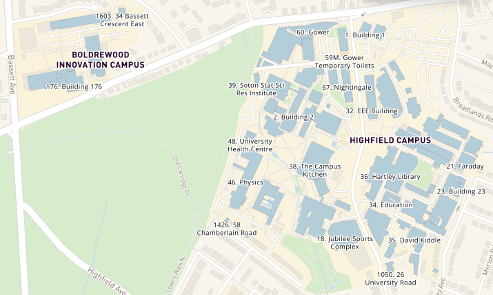

The University Campus. The Library is Building 36.